# Task1 - Exploratory Data Analysis

## 2 . time perspective

#### 2.2

- by hours: Most of the transactions occured around 1 pm, followed by 5 pm.
- by weekdays:
  - The highest amount transactions occured on Monday in Weekdays.
  - Saturday and Sunday have the lowest number of transactions.
- by months:
  - Both the amount and balance in Oct are the highest among the three months.

```python
grouped_trans_day = df.groupby(by='date').sum()
```

```python
grouped_trans_day;
```

```python
grouped_trans_day['SMA_5'] = grouped_trans_day['amount'].rolling(5).mean();
grouped_trans_day['SMA_10'] = grouped_trans_day['amount'].rolling(10).mean();
```

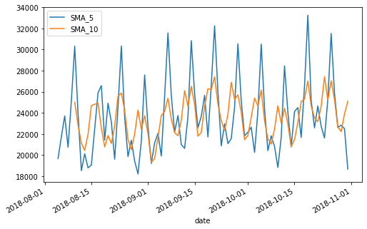

```python
grouped_trans_day[['SMA_5','SMA_10']].plot()
plt.savefig('figure/SMA_5_10.png')
```

```python
df['Weekday']=df['date'].dt.weekday
```

```python
df['Weekday']=df['Weekday'].map({
    0:'Monday',1:'Tuesday',2:'Wedneday',3:'Thursday',
    4:'Friday',5:'Saturday',6:'Sunday'})
```

```python
df.head(3)
```

|  | status | card_present_flag | account | currency | long_lat | txn_description | merchant_id | first_name | balance | date | ... | transaction_id | country | customer_id | merchant_long_lat | movement | trans_time | trans_day | trans_month | age_bin | Weekday |
| --- | --- | --- | --- | --- | --- | --- | --- | --- | --- | --- | --- | --- | --- | --- | --- | --- | --- | --- | --- | --- | --- |
| 0 | authorized | 1.0 | ****1071 | AUD | 153.41 -27.95 | POS | 81c48296-73be-44a7-befa-d053f48ce7cd | Diana | 152.705 | 2018-08-01 | ... | a623070bfead4541a6b0fff8a09e706c | Australia | CUS-2487424745 | 153.38 -27.99 | debit | 1 | 1 | August | (17, 28] | Wedneday |
| 1 | authorized | 0.0 | ****1071 | AUD | 153.41 -27.95 | SALES-POS | 830a451c-316e-4a6a-bf25-e37caedca49e | Diana | 152.705 | 2018-08-01 | ... | 13270a2a902145da9db4c951e04b51b9 | Australia | CUS-2487424745 | 151.21 -33.87 | debit | 1 | 1 | August | (17, 28] | Wedneday |
| 2 | authorized | 1.0 | ****0524 | AUD | 151.23 -33.94 | POS | 835c231d-8cdf-4e96-859d-e9d571760cf0 | Michael | 152.705 | 2018-08-01 | ... | feb79e7ecd7048a5a36ec889d1a94270 | Australia | CUS-2142601169 | 151.21 -33.87 | debit | 1 | 1 | August | (28, 38] | Wedneday |

3 rows × 26 columns

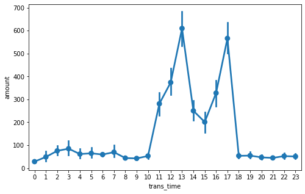

```python
ax = sns.pointplot(x="trans_time", y="amount", data=df,
                    order=set(df['trans_time'].unique()))
plt.savefig('figure/Tansaction_of_hours.png')
```

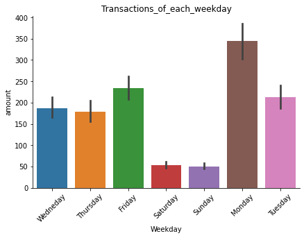

```python
sns.catplot(x='Weekday',y='amount',data=df,kind='bar',height=4, aspect=1.5 )
plt.title('Transactions_of_each_weekday')
plt.xticks(rotation=45);
plt.savefig('figure/Tansaction_of_day.png')
```

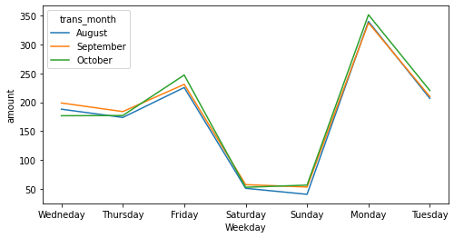

```python
plt.figure(figsize=(8, 4))
sns.lineplot(data=df , x='Weekday',
            y="amount", hue="trans_month",err_style=None)
plt.savefig('figure/tansaction_of_3month_in_day.png')
```

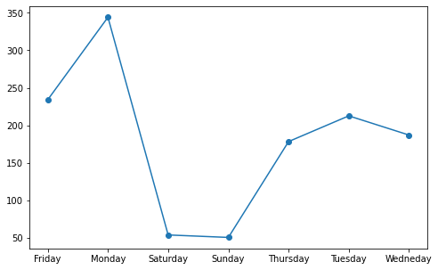

```python
mean_day=df.groupby('Weekday')['amount'].agg('mean')
plt.plot(mean_day,marker='o')
plt.savefig('figure/mean_amount_day.png')
```

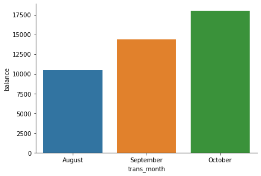

```python
sns.catplot(x = 'trans_month', y = 'balance',
            data = df, kind = 'bar',
            height = 4,aspect = 1.5,
            ci=None)
plt.savefig('figure/balance_3month.png')
```

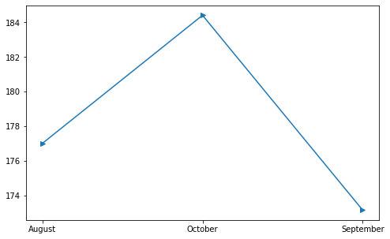

```python
mean_month=df.groupby('trans_month')['amount'].agg('mean')
plt.plot(mean_month,marker='>')
plt.savefig('figure/mean_amount_3month.png')
```

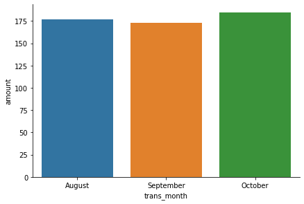

```python
sns.catplot(x = 'trans_month', y = 'amount',
            data = df,
            capsize = 0.02,ci=None,
            kind="bar",
            height = 4,aspect = 1.5)
plt.savefig('figure/amount_3month.png')
```

## 3 . gender perspective

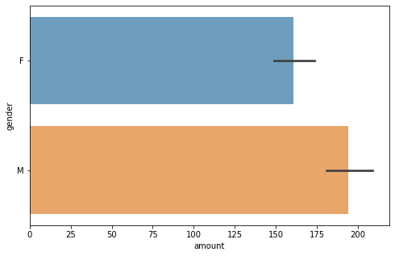

```python
sns.barplot(data=df, x="amount", y="gender",alpha=0.7)
plt.savefig('figure/gender_amount.png')
```

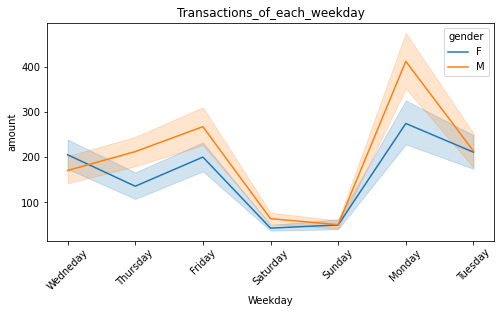

```python
plt.figure(figsize=(8, 4))
sns.lineplot(x='Weekday',y='amount',data=df ,hue='gender')
plt.title('Transactions_of_each_weekday')
plt.xticks(rotation=45);
plt.savefig('figure/gender_amount_of_day.png')
```

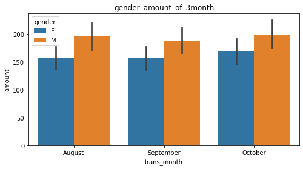

```python
plt.figure(figsize=(8, 4))
sns.barplot(x='trans_month',y='amount',data=df ,hue='gender')
plt.title('gender_amount_of_3month')
plt.xticks();
plt.savefig('figure/gender_amount_of_3month.png')
```

## 4 . location perspective

- It is clear that the amount of transactions happened in ACT is the highest of all other States, followed by NSW
- In August and October ACT has the highest transactions, however NSW was first and ACT dropped to 5th place from the top.
- Generally, Males who are from ACT and NT made the most transactions.
- For the age range 39 - 48 we can observe that males have the highest balance in QLD and TAS, and at the same age group for females, the highest balance found in VIC.
- Regarding the amount of transactions, the age group 49 - 58 for males from VIC and females from SA are the highest. SA's female age group of 59 - 68 seems to have very high number of transactions and occupy the seconds place, whereas for the same State, the males of the same age group ranked at a very low position. Relatively high is also the female age group of 29 - 38 females from QLD.

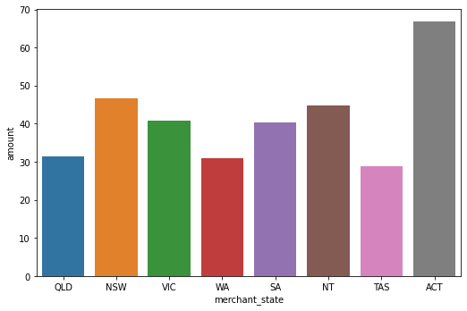

```python
plt.figure(figsize=(8.5, 5.5))
sns.barplot(data=df, x='merchant_state',
            y='amount', ci=None)
plt.savefig('figure/amount_of_state.png')
```

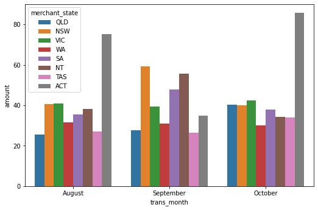

```python
plt.figure(figsize=(8.5, 5.5))
sns.barplot(data=df, x='trans_month',
            y='amount', hue="merchant_state",ci=None)
plt.savefig('figure/amount_of_state_in_3month.png')
```

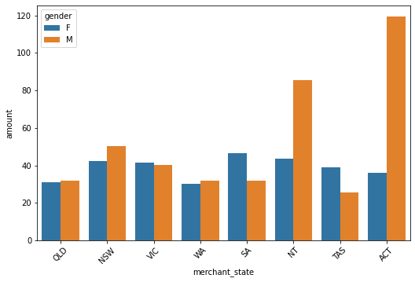

```python
plt.figure(figsize=(8.5, 5.5))
sns.barplot(x='merchant_state',y='amount',data=df ,hue='gender',ci=None)
plt.xticks(rotation=45);
plt.savefig('figure/amount_of_gender_in_states.png')
```

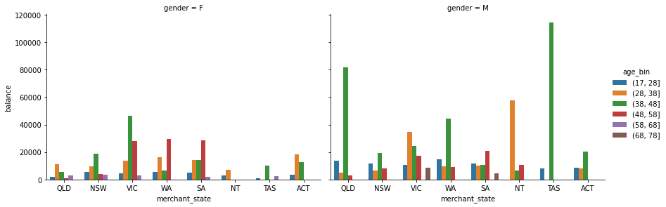

```python
sns.catplot(x = 'merchant_state', y = 'balance',
            data = df, kind = 'bar',
            hue = 'age_bin',
            height = 4,aspect = 1.5,
            col = 'gender',ci=None)
plt.savefig('figure/age_gender_balance_sates.png')
```

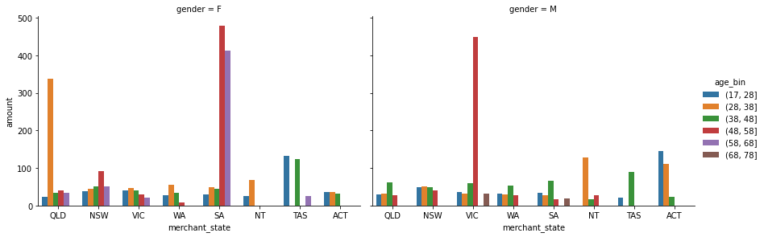

```python
sns.catplot(x = 'merchant_state', y = 'amount',
            data = df,
            hue = 'age_bin',
            col='gender',
            kind="bar",
            height = 4,
            aspect = 1.5,
            ci=None)
plt.savefig('figure/age_gender_amount_sates.png')
```

### Let's find the people of top 10 and least 10 transactions and display their names.

```python
conact_data_name = (list(df['first_name'].value_counts(sort=True).index[:10])) + \
                   (list(df['first_name'].value_counts(sort=True).index[-10:]))
```

```python
conact_data_value = (list(df['first_name'].value_counts(sort=True).nlargest(10))) + \
                    (list(df['first_name'].value_counts(sort=True).nsmallest(10)))
```

```python
from pandas import Series,DataFrame
```

```python
data_conact = {'names':conact_data_name,'values':conact_data_value}
data_conact = DataFrame(data_conact)
```

```python
data_conact['top_or_least'] = np.where(data_conact['values'] < 260,
                                       'least','top')
```

```python
data_conact['values'].dtype
```

```
dtype('int64')
```

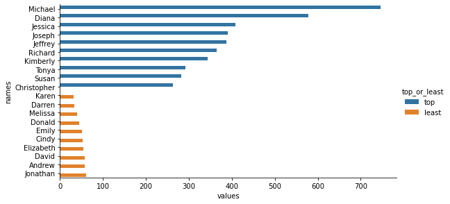

```python
sns.catplot(y='names',
           data=data_conact,
           x='values',
           kind="bar",hue='top_or_least',
           height=4, aspect=2)
plt.savefig('figure/top_and_least_10_name.png')
```

```python
from wordcloud import WordCloud
import requests
from PIL import Image
```

```python
top_50 = list(df['first_name'].value_counts(sort=True).index[:50])
```

```python
wordcloud = WordCloud(width = 500, height = 250,
                background_color ='white',
                min_font_size = 5,
                ).generate(str(top_50))
```

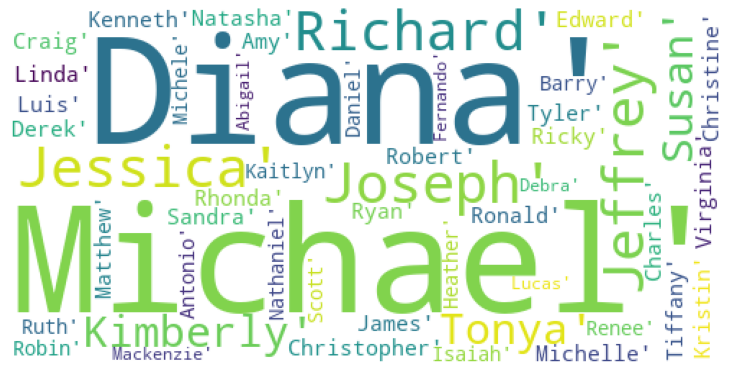

```python
plt.figure(figsize = (10, 8), facecolor = 'white')
plt.imshow(wordcloud)
plt.axis("off")
plt.tight_layout(pad = 0)
plt.savefig('figure/name_cloud.png')
```

## txn_description

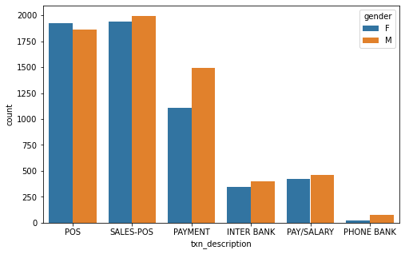

```python
sns.countplot(x="txn_description", hue="gender", data=df)
plt.savefig('figure/description_type_count.png')
```

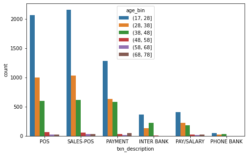

```python
sns.countplot(x="txn_description", hue="age_bin", data=df)
plt.savefig('figure/description_type_of_age_count.png')
```

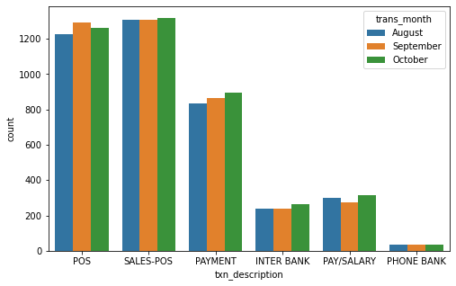

```python
sns.countplot(x="txn_description", hue="trans_month", data=df)
plt.savefig('figure/description_type_in_3month_count.png')
```

```python
y = df['txn_description'].value_counts()
y
```

```
SALES-POS     3934
POS           3783
PAYMENT       2600
PAY/SALARY     883
INTER BANK     742
PHONE BANK     101
Name: txn_description, dtype: int64
```

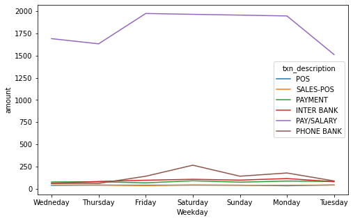

```python
sns.lineplot(data=df , x='Weekday',
            y='amount', hue="txn_description",err_style=None
            )
plt.savefig('figure/amount_of_description_type_day')
```

## debit or credit

- people in general prefer to use debit cards over credit cards.

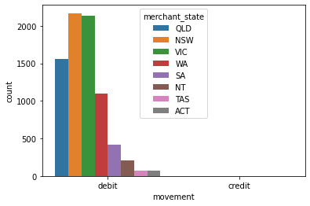

```python
plt.figure(figsize=(6,4))
sns.countplot(x='movement',hue='merchant_state',data=df)
plt.savefig('figure/debit_credit_count.png')
```

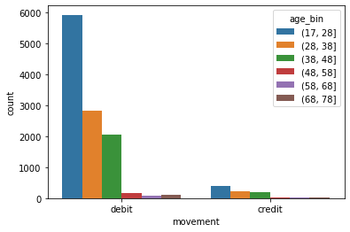

```python
plt.figure(figsize=(6,4))
sns.countplot(x='movement',hue='age_bin',data=df)
plt.savefig('figure/debit_credit_count_of_age.png')
```

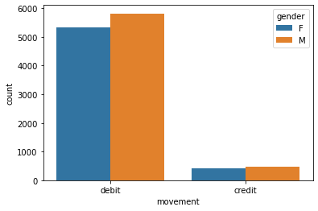

```python
plt.figure(figsize=(6,4))
sns.countplot(x='movement',hue='gender',data=df)
plt.savefig('figure/debit_credit_count_of_gender.png')
```

## I saved the above data as analysed_data.csv to visualize them in Tableau. I took screen shots that can be found below.

```python
df.to_csv('analysed_data.csv',index= False)
```

```python
pd.read_csv('analysed_data.csv').head(3)
```

|  | status | card_present_flag | account | currency | long_lat | txn_description | merchant_id | first_name | balance | date | ... | transaction_id | country | customer_id | merchant_long_lat | movement | trans_time | trans_day | trans_month | age_bin | Weekday |
| --- | --- | --- | --- | --- | --- | --- | --- | --- | --- | --- | --- | --- | --- | --- | --- | --- | --- | --- | --- | --- | --- |
| 0 | authorized | 1.0 | ****1071 | AUD | 153.41 -27.95 | POS | 81c48296-73be-44a7-befa-d053f48ce7cd | Diana | 152.705 | 2018-08-01 | ... | a623070bfead4541a6b0fff8a09e706c | Australia | CUS-2487424745 | 153.38 -27.99 | debit | 1 | 1 | August | (17, 28] | Wedneday |
| 1 | authorized | 0.0 | ****1071 | AUD | 153.41 -27.95 | SALES-POS | 830a451c-316e-4a6a-bf25-e37caedca49e | Diana | 152.705 | 2018-08-01 | ... | 13270a2a902145da9db4c951e04b51b9 | Australia | CUS-2487424745 | 151.21 -33.87 | debit | 1 | 1 | August | (17, 28] | Wedneday |
| 2 | authorized | 1.0 | ****0524 | AUD | 151.23 -33.94 | POS | 835c231d-8cdf-4e96-859d-e9d571760cf0 | Michael | 152.705 | 2018-08-01 | ... | feb79e7ecd7048a5a36ec889d1a94270 | Australia | CUS-2142601169 | 151.21 -33.87 | debit | 1 | 1 | August | (28, 38] | Wedneday |

3 rows × 26 columns

[figure not shown]

## I have created a pivot table for futher use.

```python
# pivot_data = pd.pivot_table(data = df,
#                              index = [ 'merchant_state','Weekday'],
#                              columns = 'gender',
#                              values = ['balance','amount'],
#                              aggfunc= (np.sum,np.mean,np.max)
#                              )
```

```python
# pivot_data.to_csv('pivot_data.csv',index= True,)
```

```python
# data = pd.read_csv('pivot_data.csv')
```

```python
# data[4:].to_csv('pivot_data.csv',index= False,
#                  header = ['state','Weekday',
#                            'f_max_amount', 'm_max_amount',
#                            'f_mean_amount', 'm_mean_amount',
#                            'f_sum_amount', 'f_sum_amount',
#                            'f_max_balance', 'm_max_balance',
#                            'f_mean_balance', 'm_mean_balance',
#                            'f_sum_balance', 'f_balance',
#                           ])
```

```python
# df_pivot = pd.read_csv('pivot_data.csv')
# df_pivot.head(10)
```

```python
# np.sum(df_pivot.isnull(), axis = 0)
```

```python
# df_pivot = df_pivot.fillna(int(0))
# np.sum(df_pivot.isnull(), axis = 0)
```